# Rrrr - Software for Pirates

# Setup your environment

As I said in class, you have to worry a bit about your working environment. The following chunck shows you how you could change that. However, I have simplified things a bit (from what you saw in class) to make it easier for to begin with.

For that to work you have to keep all your data files in a directory called that and all the code files (such as this one) in a directory that sits in the same sub directory. e.g. if you have a directory “data stories course” you want to have in there a directory called “data”" with the data files and a directory “code” with the code files.

Note that by default in a markdown document (i.e. an Rmd document…things are a bit different in a R document) the default active working directory is always the directory where the document is stored. So below when I load data, this is what I assume; e.g. I will load “../data/foreigners.dta”. Note that this tells the computer that to find the file you need to go one level up (that’s what “..” means) and then you go down again in the “data” directory

```r
print("hello world")
```

```
## [1] "hello world"
```

```r
7/6
```

```
## [1] 1.166667
```

when we print something shows up

```r
#mydir=paste0(dropbox_path,'/teaching/data stories')  # set this according to what applies on your computer
mydir=getwd()
print(mydir)
```

```
## [1] "C:/Users/Ralf Martin/Dropbox/datastories/datastorieshub/code"
```

```r
# e.g. mydir="c:/user/Rproject1/"
setwd(mydir)  # This is how you set a working directory in normal R code
getwd()
```

```
## [1] "C:/Users/Ralf Martin/Dropbox/datastories/datastorieshub/code"
```

```r
knitr::opts_knit$set(root.dir = getwd(), verbose = TRUE)  # This makes sure you keep the same directory in subsequent chuncks of code
```

# Some playing

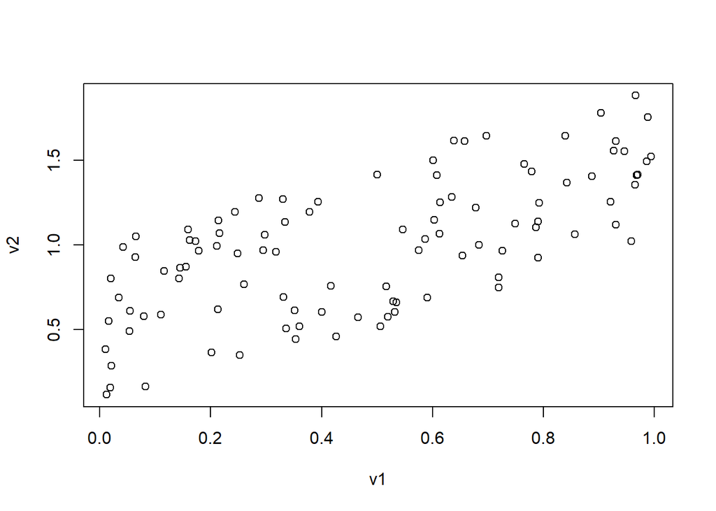

```r
  v1=runif(100)
  v2=runif(100)+v1


  plot(v1,v2)
```

# Migrants

Since they gained power in 2010 the UK Tory Junta have led a relentless campaign of scapegoating immigrants for their policy failures. Part of this is the suggestion that increased levels of immigration lead to more crime. Here we explore to what extent there is actually any evidence in the data for this.

## Load the Data

```r
 getwd()
```

```
## [1] "C:/Users/Ralf Martin/Dropbox/datastories/datastorieshub/code"
```

```r
 library(haven)   # make sure libraries such as this are installed. If not go to Tools -> Install Packages

 #df=read_dta("../data/foreigners.dta")

#ralf<-read_dta("../data/foreigners.dta")

df=read.csv("https://www.dropbox.com/s/g1w75gkw7g91zef/foreigners.csv?dl=1")
```

some stuff I wrote…

```r
print(3/7)
```

```
## [1] 0.4285714
```

## Prepare Data

```r
  newv=runif(20)
  #df['test']=newv/df$pop11
  summary(df)
```

```
##        X             crimes11          b_migr11          pop11
##  Min.   :  1.00   Min.   :   1134   Min.   : 2.241   Min.   :   2203
##  1st Qu.: 87.75   1st Qu.: 107618   1st Qu.: 4.899   1st Qu.:  94263
##  Median :174.50   Median : 160556   Median : 7.603   Median : 125746
##  Mean   :174.50   Mean   : 236988   Mean   :11.226   Mean   : 161434
##  3rd Qu.:261.25   3rd Qu.: 309377   3rd Qu.:12.382   3rd Qu.: 200247
##  Max.   :348.00   Max.   :1714295   Max.   :55.161   Max.   :1072372
##                   NA's   :24        NA's   :9        NA's   :9
##            area
##              :  9
##  Adur        :  1
##  Allerdale   :  1
##  Amber Valley:  1
##  Arun        :  1
##  Ashfield    :  1
##  (Other)     :334
```

```r
  summary(df$crimes11)
```

```
##    Min. 1st Qu.  Median    Mean 3rd Qu.    Max.    NA's
##    1134  107618  160556  236988  309377 1714295      24
```

```r
  summary(df$pop11)
```

```
##    Min. 1st Qu.  Median    Mean 3rd Qu.    Max.    NA's
##    2203   94263  125746  161434  200247 1072372       9
```

```r
  crimes11=df$crimes11

  summary(crimes11)
```

```
##    Min. 1st Qu.  Median    Mean 3rd Qu.    Max.    NA's
##    1134  107618  160556  236988  309377 1714295      24
```

```r
  df['crimesPc']=df$crimes11/df$pop11
```

## Look at data

A scatter plot

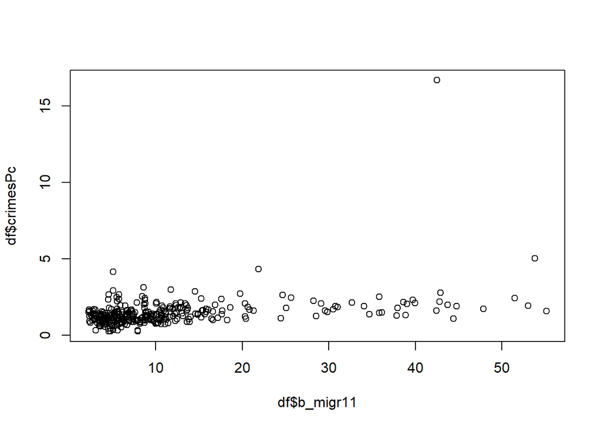

```r
plot(df$b_migr11,df$crimesPc)


library(ggplot2)
```

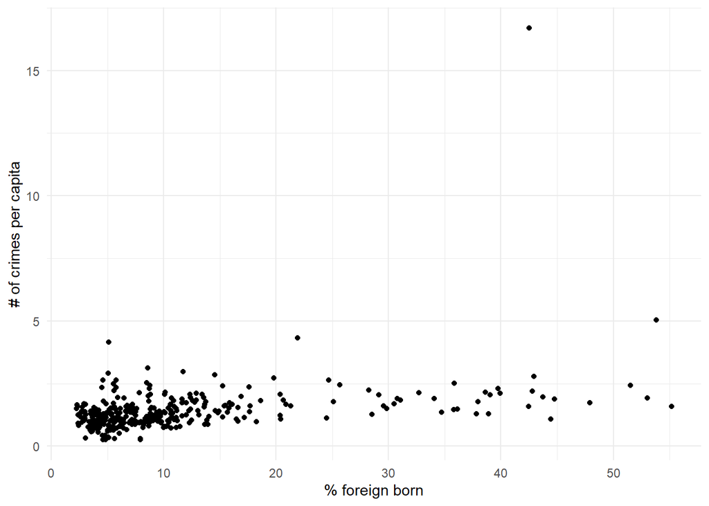

```r
ggplot(df, aes(x = b_migr11, y = crimesPc)) +
    geom_point()+theme_minimal()+
    xlab("% foreign born")+ylab("# of crimes per capita")
```

How about leaving the City of London out?

```r
df[df$crimesPc>5,"area"]
```

```
##  [1] <NA>           <NA>           <NA>           <NA>           <NA>
##  [6] <NA>           <NA>           <NA>           <NA>           <NA>
## [11] <NA>           <NA>           <NA>           <NA>           <NA>
## [16] City of London Westminster    <NA>           <NA>           <NA>
## [21] <NA>           <NA>           <NA>           <NA>           <NA>
## [26] <NA>
## 340 Levels:  Adur Allerdale Amber Valley Arun Ashfield ... York
```

```r
df[df$crimesPc>4.5,"area"]
```

```
##  [1] <NA>           <NA>           <NA>           <NA>           <NA>
##  [6] <NA>           <NA>           <NA>           <NA>           <NA>
## [11] <NA>           <NA>           <NA>           <NA>           <NA>
## [16] City of London Westminster    <NA>           <NA>           <NA>
## [21] <NA>           <NA>           <NA>           <NA>           <NA>
## [26] <NA>
## 340 Levels:  Adur Allerdale Amber Valley Arun Ashfield ... York
```

```r
df[df$crimesPc>4.5,c("area","crimesPc")]
```

```
##                 area  crimesPc
## NA              <NA>        NA
## NA.1            <NA>        NA
## NA.2            <NA>        NA
## NA.3            <NA>        NA
## NA.4            <NA>        NA
## NA.5            <NA>        NA
## NA.6            <NA>        NA
## NA.7            <NA>        NA
## NA.8            <NA>        NA
## NA.9            <NA>        NA
## NA.10           <NA>        NA
## NA.11           <NA>        NA
## NA.12           <NA>        NA
## NA.13           <NA>        NA
## NA.14           <NA>        NA
## 285   City of London 16.690982
## 317      Westminster  5.030381
## NA.15           <NA>        NA
## NA.16           <NA>        NA
## NA.17           <NA>        NA
## NA.18           <NA>        NA
## NA.19           <NA>        NA
## NA.20           <NA>        NA
## NA.21           <NA>        NA
## NA.22           <NA>        NA
## NA.23           <NA>        NA
```

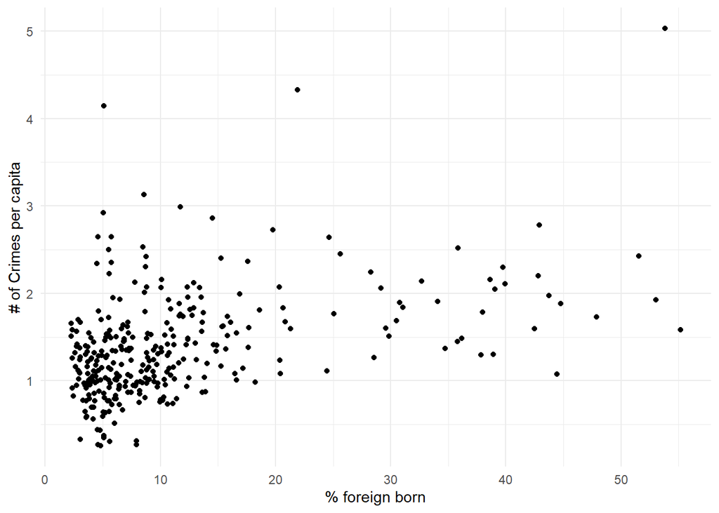

```r
dfx =   df[df$crimesPc<10,]


ggplot(dfx, aes(x = b_migr11, y = crimesPc)) +
    geom_point()+theme_minimal()+
    xlab("% foreign born")+ylab("# of Crimes per capita")
```

What about a correlation?

```r
library(dplyr)
#summary(ralf$crimes11)

cor(df[,c("crimes11","crimesPc","b_migr11")],use="complete.obs")
```

```
##           crimes11  crimesPc  b_migr11
## crimes11 1.0000000 0.3101539 0.4874797
## crimesPc 0.3101539 1.0000000 0.3810661
## b_migr11 0.4874797 0.3810661 1.0000000
```

```r
cor(dfx[,c("crimesPc","b_migr11")],use="complete.obs")
```

```
##           crimesPc  b_migr11
## crimesPc 1.0000000 0.4331594
## b_migr11 0.4331594 1.0000000
```

```r
df %>% select(crimesPc,b_migr11) %>% cor(use="complete.obs")
```

```
##           crimesPc  b_migr11
## crimesPc 1.0000000 0.3810661
## b_migr11 0.3810661 1.0000000
```

```r
library(corrr)
test=df %>% select(crimesPc,b_migr11)
df %>% select(crimesPc,b_migr11) %>%  correlate()
```

```
##
## Correlation method: 'pearson'
## Missing treated using: 'pairwise.complete.obs'
```

```
## # A tibble: 2 x 3
##   rowname  crimesPc b_migr11
##   <chr>       <dbl>    <dbl>
## 1 crimesPc   NA        0.381
## 2 b_migr11    0.381   NA
```

Or trend line?

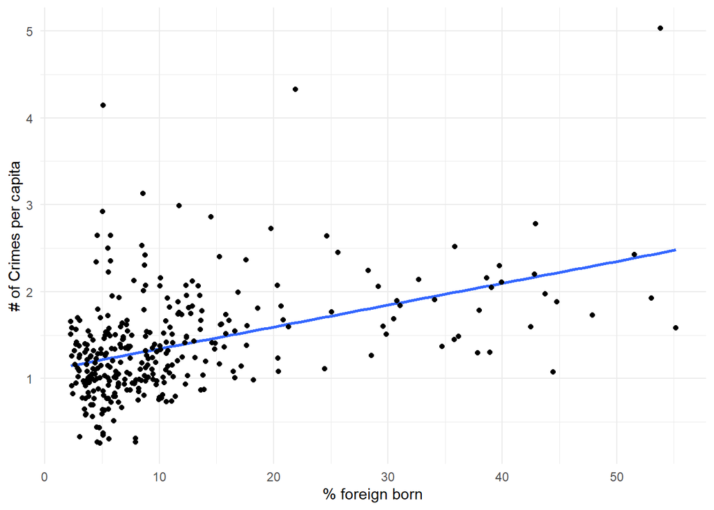

```r
library(ggplot2)
ggplot(dfx, aes(x = b_migr11, y = crimesPc)) +
    geom_smooth(method = "lm", se = FALSE) +
    geom_point()+theme_minimal()+
    xlab("% foreign born")+ylab("# of Crimes per capita")
```

```r
  reg1=lm(crimesPc~b_migr11,df)

  reg1_df=df[-reg1$na.action,]  # get rid of missing values


  summary(reg1)
```

```
##
## Call:
## lm(formula = crimesPc ~ b_migr11, data = df)
##
## Residuals:
##     Min      1Q  Median      3Q     Max
## -1.5886 -0.3789 -0.1038  0.2046 14.0988
##
## Coefficients:
##             Estimate Std. Error t value Pr(>|t|)
## (Intercept) 0.992957   0.079387  12.508  < 2e-16 ***
## b_migr11    0.037630   0.005088   7.396 1.23e-12 ***
## ---
## Signif. codes:  0 '***' 0.001 '**' 0.01 '*' 0.05 '.' 0.1 ' ' 1
##
## Residual standard error: 0.9674 on 322 degrees of freedom
##   (24 observations deleted due to missingness)
## Multiple R-squared:  0.1452, Adjusted R-squared:  0.1426
## F-statistic:  54.7 on 1 and 322 DF,  p-value: 1.226e-12
```

```r
  summary(df$b_migr11)
```

```
##    Min. 1st Qu.  Median    Mean 3rd Qu.    Max.    NA's
##   2.241   4.899   7.603  11.226  12.382  55.161       9
```

```r
  #summary(lm(crimesPc~b_migr11,dfx))
```

Notice that the residulas from a regression are not correlated

```r
  reg1_df['residuals']= reg1$residuals


  cor(reg1_df[,c("residuals","b_migr11")],use="complete.obs")
```

```
##               residuals      b_migr11
## residuals  1.000000e+00 -2.474525e-17
## b_migr11  -2.474525e-17  1.000000e+00
```

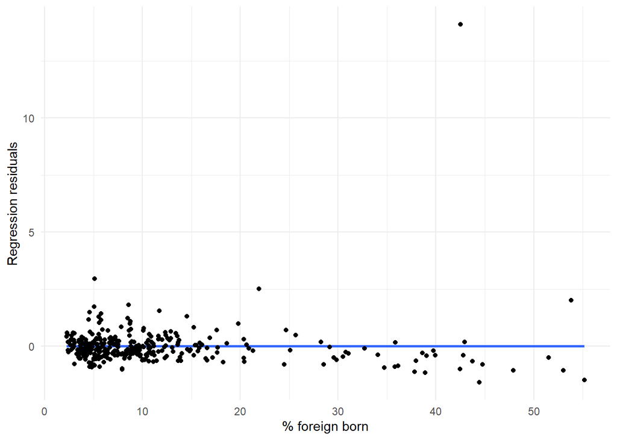

```r
  ggplot(reg1_df, aes(x = b_migr11, y = residuals)) +
    geom_smooth(method = "lm", se = FALSE) +
    geom_point()+theme_minimal()+
    xlab("% foreign born")+ylab("Regression residuals")
```

# Some further perspectives on the data

Just some basic numbers

```r
#library(psych)
#describe(df$crimesPc)
#describe(df$b_migr11)

library(Hmisc)
Hmisc::describe(df[,c("b_migr11","crimesPc")])
```

```
## df[, c("b_migr11", "crimesPc")]
##
##  2  Variables      348  Observations
## --------------------------------------------------------------------------------
## b_migr11
##        n  missing distinct     Info     Mean      Gmd      .05      .10
##      339        9      339        1    11.23    9.593    3.013    3.687
##      .25      .50      .75      .90      .95
##    4.899    7.603   12.382   25.201   38.024
##
## lowest :  2.240523  2.279650  2.342227  2.361519  2.373362
## highest: 47.886591 51.521316 53.043116 53.820812 55.161434
## --------------------------------------------------------------------------------
## crimesPc
##        n  missing distinct     Info     Mean      Gmd      .05      .10
##      324       24      324        1    1.425   0.7209   0.6406   0.7759
##      .25      .50      .75      .90      .95
##   0.9905   1.2901   1.6582   2.1164   2.4465
##
## lowest :  0.2544352  0.2669489  0.2685578  0.3042361  0.3114384
## highest:  3.1323595  4.1454223  4.3277037  5.0303810 16.6909820
##
## Value        0.2   0.4   0.6   0.8   1.0   1.2   1.4   1.6   1.8   2.0   2.2
## Frequency      3     7    12    32    64    46    49    38    22    17    10
## Proportion 0.009 0.022 0.037 0.099 0.198 0.142 0.151 0.117 0.068 0.052 0.031
##
## Value        2.4   2.6   2.8   3.0   3.2   4.2   4.4   5.0  16.6
## Frequency      9     5     3     2     1     1     1     1     1
## Proportion 0.028 0.015 0.009 0.006 0.003 0.003 0.003 0.003 0.003
##
## For the frequency table, variable is rounded to the nearest 0.2
## --------------------------------------------------------------------------------
```

```r
summary(df$b_migr11)
```

```
##    Min. 1st Qu.  Median    Mean 3rd Qu.    Max.    NA's
##   2.241   4.899   7.603  11.226  12.382  55.161       9
```

```r
summary(df$crimesPc)
```

```
##    Min. 1st Qu.  Median    Mean 3rd Qu.    Max.    NA's
##  0.2544  0.9905  1.2901  1.4251  1.6582 16.6910      24
```

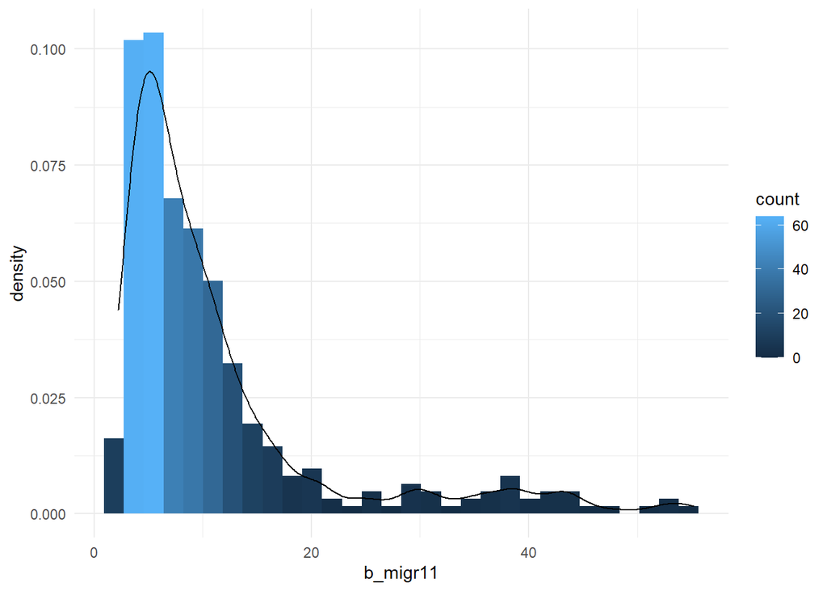

```r
library(scales)
library(magrittr)



ggplot(data = df, aes(b_migr11)) +
  geom_histogram( bins=30,              aes(y = ..density.., fill=..count..)) +
  geom_density()+theme_minimal()
```

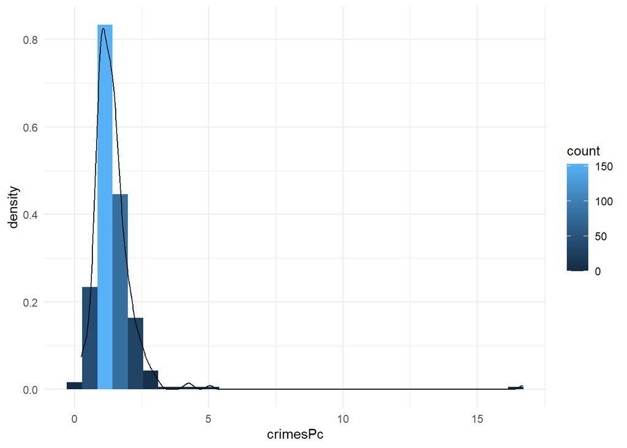

```r
ggplot(data = df, aes(crimesPc)) +
  geom_histogram( bins=30,              aes(y = ..density.., fill=..count..)) +
  geom_density()+theme_minimal()
```